# Управление пользователями и группами

Майоров Дмитрий Андреевич

## Докладчик

- Майоров Дмитрий андреевич

## Цель работы

Получение представления о работе с учетными записями пользователей и группами пользователей в опреационной системе типа Linux

## Выполнение лабораторной работы

Определяем какую учетную запись используем, выводим на экран более подробную информацию. uid - ID пользователя и имя. gid - ID основной группы. groups - группы, в которых состоит пользователь.

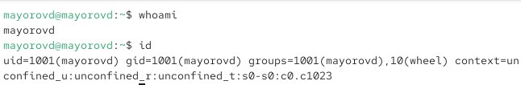

Рисунок 1: Получение информации о пользователе

## Выполнение лабораторной работы

Переключаемся в учетную запись root и выводим на экран более подробную информацию.uid - ID пользователя и имя. gid - ID основной группы. groups - группы, в которых состоит пользователь.

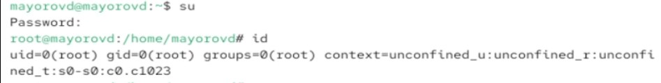

Рисунок 2: Получение информации о пользователе root

## Выполнение лабораторной работы

Просматриваем в безопасном режиме файл /etc/sudoers в текстовом редакторе vi. Убеждаемся что в файле есть строка %wheel ALL=(ALL) ALL. Мы используем редактор visudo, т.к. если работать через обычный текстовый редактор, sudo перстанет работать для всех пользователей. Группа wheel - группа админимтраторов Linux.

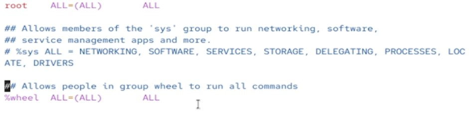

Рисунок 3: Просмотр файла через редактор vi

## Выполнение лабораторной работы

Создаем пользователя alice. Убеждаемся что он добавлен в группу whell. Задаем пароль.

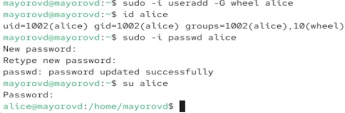

Рисунок 4: Создание пользователя alice

## Выполнение лабораторной работы

Создаем пользователя bob. Задаем пароль. Смотрим в какие группы входит пользователь.

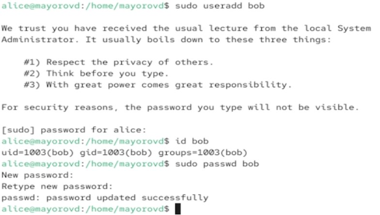

Рисунок 5: Создание пользователя bob

## Выполнение лабораторной работы

Пернходим в учетную запись root. Открываем файл используя vim.

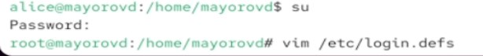

Рисунок 6: Окрытие файла

## Выполнение лабораторной работы

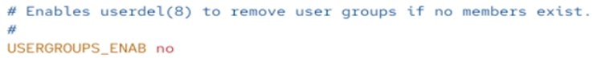

Рисунок 8: Параметр USERGROUPS_ENAB no

## Выполнение лабораторной работы

Создаем каталоги Pictures и Documents.

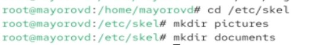

## Выполнение лабораторной работы

Создаем пользователя Carol. Задаем пароль

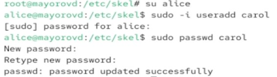

Рисунок 10: Создание пользователя Carol

## Выполнение лабораторной работы

Просмтариваем информацию о Carol. Убеждаемся, что каталоги Pictures и Documents были созданы в домашнем каталоге пользователя Carol.

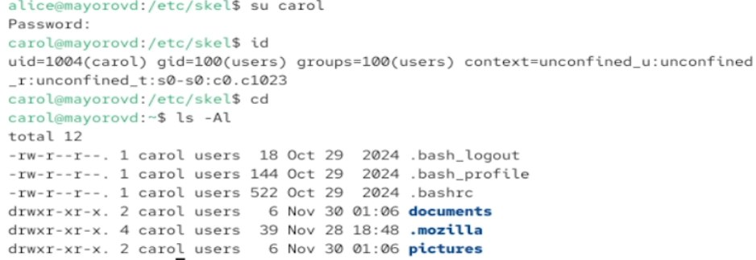

Рисунок 11: Информация пользователя Carol

## Выполнение лабораторной работы

Смотрим строку записи о пароле пользователя CArol. $y$ - алгоритм хеширования. Длинная строка после $y$ - хеш пароля. 20421 - дата с последнего изменения пароля. 0 - минимальное время до следующей смены. 99999 - максимальное время дейсвтия пароля.

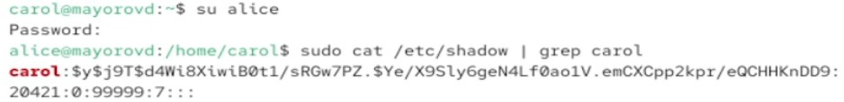

Рисунок 12: Запись о пароле пользователя Carol

## Выполнение лабораторной работы

Меняем свойства пароля

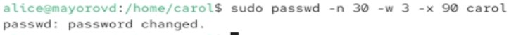

Рисунок 13: Меняем свойства пароля

## Выполнение лабораторной работы

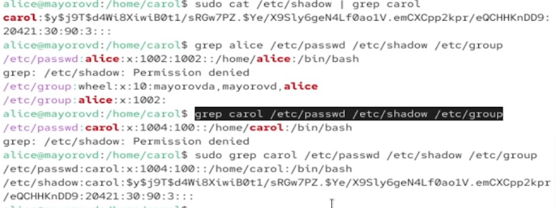

Рисунок 14

## Выполнение лабораторной работы

СОздаем группы main и third.

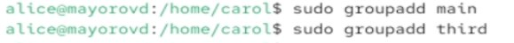

Рисунок 15: Создание групп

## Выполнение лабораторной работы

Добавляем пользователей в нужные группы.

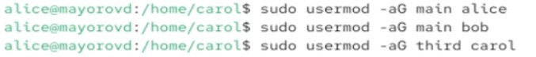

Рисунок 16

## Выполнение лабораторной работы

Убеждаемся что пользователь CArol правильно добавлен в группу third.

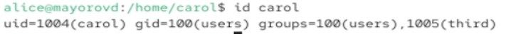

Рисунок 17

## Выводы

Мы получили представление о работе с учетными записями пользователей и группами пользователей в опреационной системе типа Linux